# Explore_bikeshare_data-Copy1

### Explore Bike Share Data

For this project, your goal is to ask and answer three questions about the available bikeshare data from Washington, Chicago, and New York. This notebook can be submitted directly through the workspace when you are confident in your results.

You will be graded against the project [Rubric](https://review.udacity.com/#!/rubrics/2508/view) by a mentor after you have submitted. To get you started, you can use the template below, but feel free to be creative in your solutions!

### Importing and Examining the Data

```r
ny = read.csv('new_york_city.csv')
was = read.csv('washington.csv')
chi = read.csv('chicago.csv')
```

```r
head(ny)
```

| X | Start.Time | End.Time | Trip.Duration | Start.Station | End.Station | User.Type | Gender | Birth.Year |
| --- | --- | --- | --- | --- | --- | --- | --- | --- |
| 5688089 | 2017-06-11 14:55:05 | 2017-06-11 15:08:21 | 795 | Suffolk St & Stanton St | W Broadway & Spring St | Subscriber | Male | 1998 |
| 4096714 | 2017-05-11 15:30:11 | 2017-05-11 15:41:43 | 692 | Lexington Ave & E 63 St | 1 Ave & E 78 St | Subscriber | Male | 1981 |
| 2173887 | 2017-03-29 13:26:26 | 2017-03-29 13:48:31 | 1325 | 1 Pl & Clinton St | Henry St & Degraw St | Subscriber | Male | 1987 |
| 3945638 | 2017-05-08 19:47:18 | 2017-05-08 19:59:01 | 703 | Barrow St & Hudson St | W 20 St & 8 Ave | Subscriber | Female | 1986 |
| 6208972 | 2017-06-21 07:49:16 | 2017-06-21 07:54:46 | 329 | 1 Ave & E 44 St | E 53 St & 3 Ave | Subscriber | Male | 1992 |
| 1285652 | 2017-02-22 18:55:24 | 2017-02-22 19:12:03 | 998 | State St & Smith St | Bond St & Fulton St | Subscriber | Male | 1986 |

```r
head(was)
```

| X | Start.Time | End.Time | Trip.Duration | Start.Station | End.Station | User.Type |
| --- | --- | --- | --- | --- | --- | --- |
| 1621326 | 2017-06-21 08:36:34 | 2017-06-21 08:44:43 | 489.066 | 14th & Belmont St NW | 15th & K St NW | Subscriber |
| 482740 | 2017-03-11 10:40:00 | 2017-03-11 10:46:00 | 402.549 | Yuma St & Tenley Circle NW | Connecticut Ave & Yuma St NW | Subscriber |
| 1330037 | 2017-05-30 01:02:59 | 2017-05-30 01:13:37 | 637.251 | 17th St & Massachusetts Ave NW | 5th & K St NW | Subscriber |
| 665458 | 2017-04-02 07:48:35 | 2017-04-02 08:19:03 | 1827.341 | Constitution Ave & 2nd St NW/DOL | M St & Pennsylvania Ave NW | Customer |
| 1481135 | 2017-06-10 08:36:28 | 2017-06-10 09:02:17 | 1549.427 | Henry Bacon Dr & Lincoln Memorial Circle NW | Maine Ave & 7th St SW | Subscriber |
| 1148202 | 2017-05-14 07:18:18 | 2017-05-14 07:24:56 | 398.000 | 1st & K St SE | Eastern Market Metro / Pennsylvania Ave & 7th St SE | Subscriber |

```r
head(chi)
```

| X | Start.Time | End.Time | Trip.Duration | Start.Station | End.Station | User.Type | Gender | Birth.Year |
| --- | --- | --- | --- | --- | --- | --- | --- | --- |
| 1423854 | 2017-06-23 15:09:32 | 2017-06-23 15:14:53 | 321 | Wood St & Hubbard St | Damen Ave & Chicago Ave | Subscriber | Male | 1992 |
| 955915 | 2017-05-25 18:19:03 | 2017-05-25 18:45:53 | 1610 | Theater on the Lake | Sheffield Ave & Waveland Ave | Subscriber | Female | 1992 |
| 9031 | 2017-01-04 08:27:49 | 2017-01-04 08:34:45 | 416 | May St & Taylor St | Wood St & Taylor St | Subscriber | Male | 1981 |
| 304487 | 2017-03-06 13:49:38 | 2017-03-06 13:55:28 | 350 | Christiana Ave & Lawrence Ave | St. Louis Ave & Balmoral Ave | Subscriber | Male | 1986 |
| 45207 | 2017-01-17 14:53:07 | 2017-01-17 15:02:01 | 534 | Clark St & Randolph St | Desplaines St & Jackson Blvd | Subscriber | Male | 1975 |
| 1473887 | 2017-06-26 09:01:20 | 2017-06-26 09:11:06 | 586 | Clinton St & Washington Blvd | Canal St & Taylor St | Subscriber | Male | 1990 |

### Get Libraries

```r
# Get Libraries
library(dplyr)
library(tidyr)
library(ggplot2)
library(scales)
library(lubridate)
library(grid)
```

## Question 1: What are the most popular times for bike rentals?

### 1A - Make a combined dataset

```r
# tweak the washington data (add columns gender & dob)
was$Gender <- ""
was$Birth.Year <- NA

# add a city column to each dataset
chi$City <- "Chicago"
was$City <- "Washington"
ny$City <- "NewYork"

#combine datasets
allCities <- rbind(chi, ny, was)

# check data structure
str(allCities)
allCities$City <- as.factor(allCities$City)

# fix the Unknown Gender Transactions
allCities$Gender <- as.character(allCities$Gender)
allCities$Gender[allCities$Gender == ""] <- "Unknown"
allCities$Gender <- as.factor(allCities$Gender)
summary(allCities$Gender)
str(allCities)
```

```
'data.frame':	152451 obs. of  10 variables:
 $ X            : int  1423854 955915 9031 304487 45207 1473887 961916 65924 606841 135470 ...
 $ Start.Time   : Factor w/ 143945 levels "2017-01-01 00:40:14",..: 7876 5303 73 1721 267 8173 5347 368 3376 795 ...
 $ End.Time     : Factor w/ 143948 levels "2017-01-01 00:46:32",..: 7876 5303 73 1722 267 8173 5346 368 3376 796 ...
 $ Trip.Duration: num  321 1610 416 350 534 586 281 723 689 493 ...
 $ Start.Station: Factor w/ 1585 levels "2112 W Peterson Ave",..: 468 424 291 80 103 119 22 255 374 420 ...
 $ End.Station  : Factor w/ 1586 levels "","2112 W Peterson Ave",..: 132 381 469 409 151 70 467 251 200 118 ...
 $ User.Type    : Factor w/ 3 levels "","Customer",..: 3 3 3 3 3 3 3 2 3 3 ...
 $ Gender       : Factor w/ 3 levels "","Female","Male": 3 2 3 3 3 3 2 1 3 3 ...
 $ Birth.Year   : num  1992 1992 1981 1986 1975 ...
 $ City         : chr  "Chicago" "Chicago" "Chicago" "Chicago" ...
```

**Female**

13882

**Male**

42360

**Unknown**

96209

```
'data.frame':	152451 obs. of  10 variables:
 $ X            : int  1423854 955915 9031 304487 45207 1473887 961916 65924 606841 135470 ...
 $ Start.Time   : Factor w/ 143945 levels "2017-01-01 00:40:14",..: 7876 5303 73 1721 267 8173 5347 368 3376 795 ...
 $ End.Time     : Factor w/ 143948 levels "2017-01-01 00:46:32",..: 7876 5303 73 1722 267 8173 5346 368 3376 796 ...
 $ Trip.Duration: num  321 1610 416 350 534 586 281 723 689 493 ...
 $ Start.Station: Factor w/ 1585 levels "2112 W Peterson Ave",..: 468 424 291 80 103 119 22 255 374 420 ...
 $ End.Station  : Factor w/ 1586 levels "","2112 W Peterson Ave",..: 132 381 469 409 151 70 467 251 200 118 ...
 $ User.Type    : Factor w/ 3 levels "","Customer",..: 3 3 3 3 3 3 3 2 3 3 ...
 $ Gender       : Factor w/ 3 levels "Female","Male",..: 2 1 2 2 2 2 1 3 2 2 ...
 $ Birth.Year   : num  1992 1992 1981 1986 1975 ...
 $ City         : Factor w/ 3 levels "Chicago","NewYork",..: 1 1 1 1 1 1 1 1 1 1 ...
```

### 1B - Fix the Time Columns

```r
allCities$Start.Time <-  as.POSIXct(x = allCities$Start.Time,
                                     tz = "",
                                     format = "%Y-%m-%d %H:%M:%S")


allCities$End.Time <-  as.POSIXct(x = allCities$End.Time,
                                    tz = "",
                                    format = "%Y-%m-%d %H:%M:%S")

str(allCities)
```

```
'data.frame':	152451 obs. of  10 variables:
 $ X            : int  1423854 955915 9031 304487 45207 1473887 961916 65924 606841 135470 ...
 $ Start.Time   : POSIXct, format: "2017-06-23 15:09:32" "2017-05-25 18:19:03" ...
 $ End.Time     : POSIXct, format: "2017-06-23 15:14:53" "2017-05-25 18:45:53" ...
 $ Trip.Duration: num  321 1610 416 350 534 586 281 723 689 493 ...
 $ Start.Station: Factor w/ 1585 levels "2112 W Peterson Ave",..: 468 424 291 80 103 119 22 255 374 420 ...
 $ End.Station  : Factor w/ 1586 levels "","2112 W Peterson Ave",..: 132 381 469 409 151 70 467 251 200 118 ...
 $ User.Type    : Factor w/ 3 levels "","Customer",..: 3 3 3 3 3 3 3 2 3 3 ...
 $ Gender       : Factor w/ 3 levels "Female","Male",..: 2 1 2 2 2 2 1 3 2 2 ...
 $ Birth.Year   : num  1992 1992 1981 1986 1975 ...
 $ City         : Factor w/ 3 levels "Chicago","NewYork",..: 1 1 1 1 1 1 1 1 1 1 ...
```

### 1C - Get Parts of the Dates in Separate Columns and Set Factor Levels

```r
allCities$TripYear <- year(allCities$Start.Time)
allCities$TripMonth <- months.POSIXt(allCities$Start.Time)
allCities$TripDayNum <- day(allCities$Start.Time)
allCities$Trip.Day <- weekdays.POSIXt(allCities$Start.Time)
allCities$TripHour <- hour(allCities$Start.Time)
allCities$Trip.Minute <- minute(allCities$Start.Time)
allCities$Trip.Quarter.Hour <- ifelse(allCities$Trip.Minute <=15, 1,
                                      ifelse(allCities$Trip.Minute <=30, 2,
                                             ifelse(allCities$Trip.Minute <= 45, 3, 4)))
```

```r
allCities$TripMonth <- factor(allCities$TripMonth,
                              levels = c("January", "February", "March",
                                         "April", "May", "June"),
                              ordered = is.ordered(allCities$TripMonth))

allCities$TripDayNum <- factor(allCities$TripDayNum,
                               levels = c(seq(1:31)),
                               ordered = is.ordered(allCities$TripDayNum))

allCities$Trip.Day <- factor(allCities$Trip.Day,
                             levels = c("Sunday",
                                        "Monday",
                                        "Tuesday",
                                        "Wednesday",
                                        "Thursday",
                                        "Friday",
                                        "Saturday"),
                             ordered = is.ordered(allCities$Trip.Day))

allCities$TripHour <- factor(allCities$TripHour,
                             levels = seq(1:24),
                             ordered = is.ordered(allCities$TripHour))

allCities$Trip.Quarter.Hour <- factor(allCities$Trip.Quarter.Hour,
                                      levels = seq(1:4),
                                      ordered = is.ordered(allCities$Trip.Quarter.Hour))
```

### 1D - Data is ready, now to graph the data

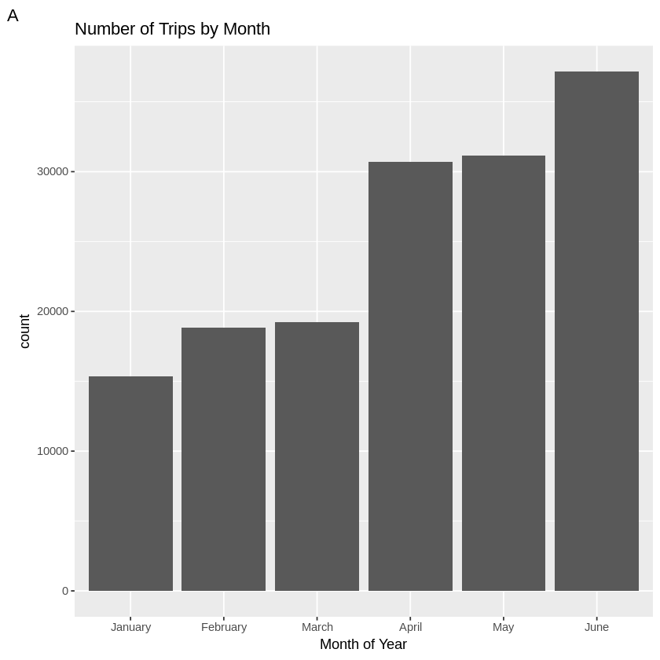

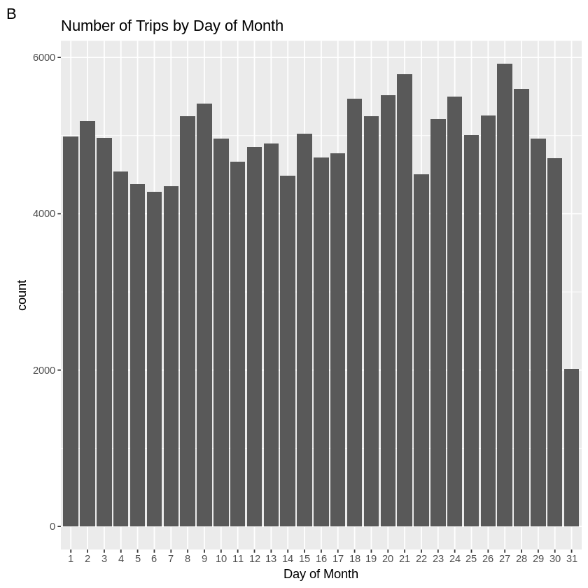

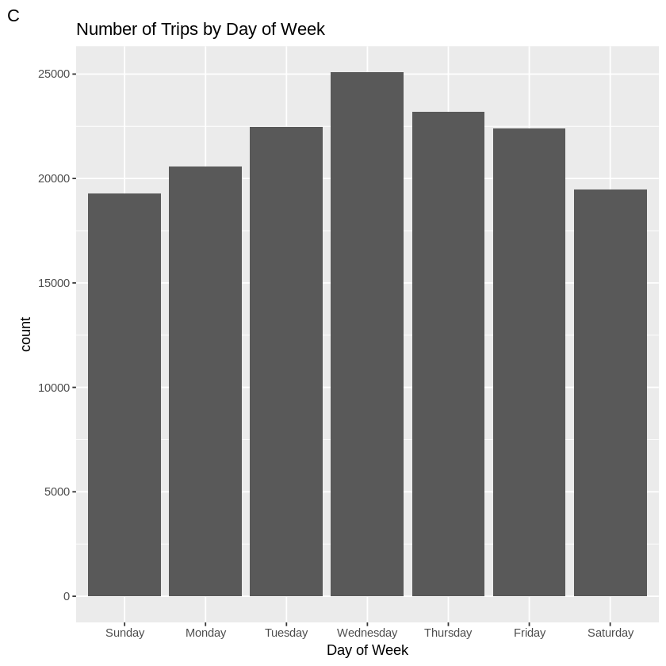

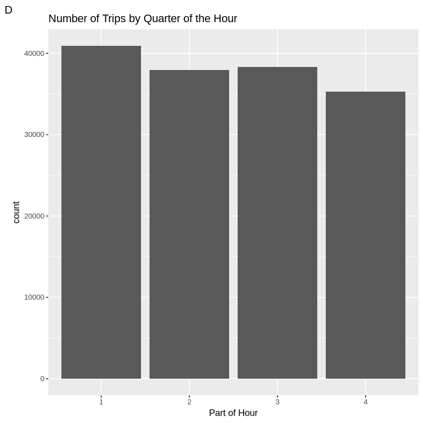

```r
allCities <- allCities[!is.na(allCities$Trip.Duration) , ] # two rows had no durations

months <- ggplot(data = allCities) +
  geom_histogram(aes(x = factor(TripMonth,
                                levels = c("January", "February", "March",
                                           "April", "May", "June"),
                                ordered = is.ordered(TripMonth))),
                     stat = "count") +
  labs(x = "Month of Year",
       title = "Number of Trips by Month",
       tag = "A")
months

dayNums <- ggplot(data = allCities) +
  geom_histogram(aes(x = factor(TripDayNum,
                                levels = c(seq(1:31)),
                                ordered = is.ordered(TripDayNum))),
                 stat = "count") +
  labs(x = "Day of Month",
       title = "Number of Trips by Day of Month",
       tag = "B")
dayNums

wkDays <- ggplot(data = allCities) +
  geom_histogram(aes(x = Trip.Day),
                 stat = "count") +
  labs(x = "Day of Week",
       title = "Number of Trips by Day of Week",
      tag = "C")
wkDays

qtHour <- ggplot(data = allCities) +
  geom_histogram(aes(x = Trip.Quarter.Hour),
                 stat = "count") +
  labs(x = "Part of Hour",
       title = "Number of Trips by Quarter of the Hour",
      tag = "D")
qtHour

# grid.newpage()
# grid.arrange(months, dayNums, wkDays, qtHour, nrow = 2,
#             top = textGrob(label = "Popular Times of Travel",
#                            gp = gpar(fontsize = 20, col = "red")))
```

### Answer 1:

A - It would seem that the closer to Summer, the greater the demand for bicycles  
B - There is no real pattern to be found in the day of the month. I assume the lesser number of months with 31 days leads to the low count for the 31st day  
C - I thought the weekends would be the most popular days for bike rentals, instead it starts out low, rises to Wednesday then decreases back down to starting levels at the end of the week  
D - Rentals seem to occur towards the start of the hour. I can't think of a rationale for that.

## Question 2 - Who Cycles More?

### 2A - Get Summary Stats

```r
cityStats <- allCities %>% group_by(City) %>% summarise(ave = mean(Trip.Duration, na.rm = T),
                                                        std = sd(Trip.Duration, na.rm = T))

genderStats <- allCities %>% group_by(Gender) %>% summarise(ave = mean(Trip.Duration, na.rm = T),
                                                          std = sd(Trip.Duration, na.rm = T))

monthStats <- allCities %>% group_by(TripMonth) %>% summarise(ave = mean(Trip.Duration, na.rm = T),
                                                            std = sd(Trip.Duration, na.rm = T))
```

### 2B - Plot Graphs

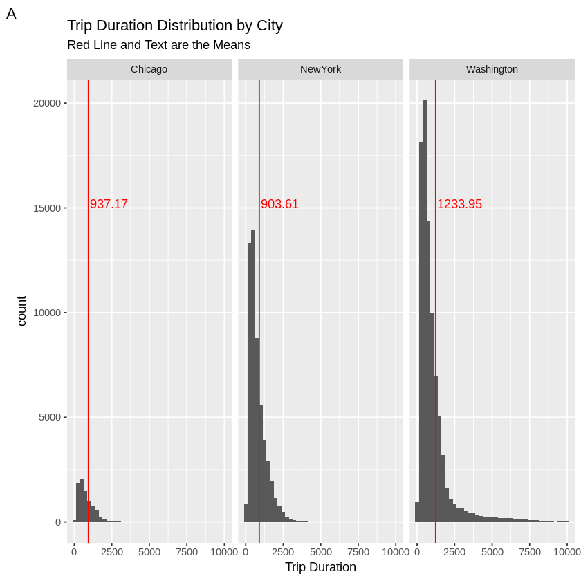

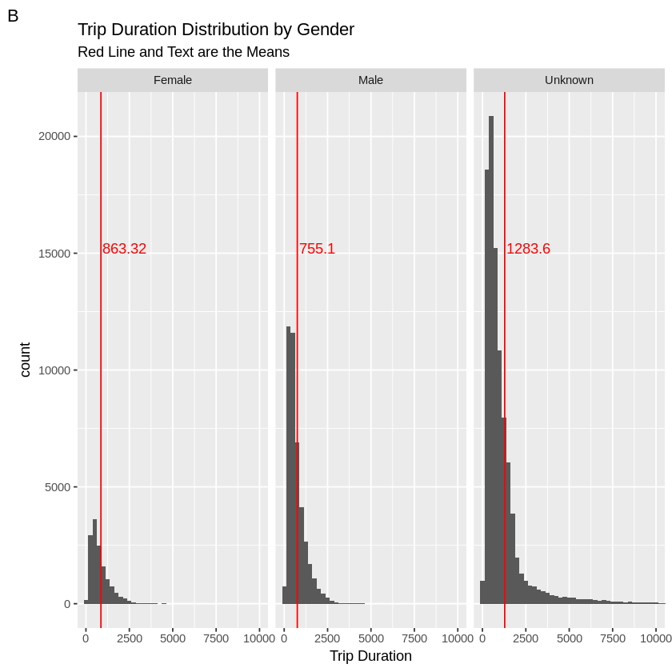

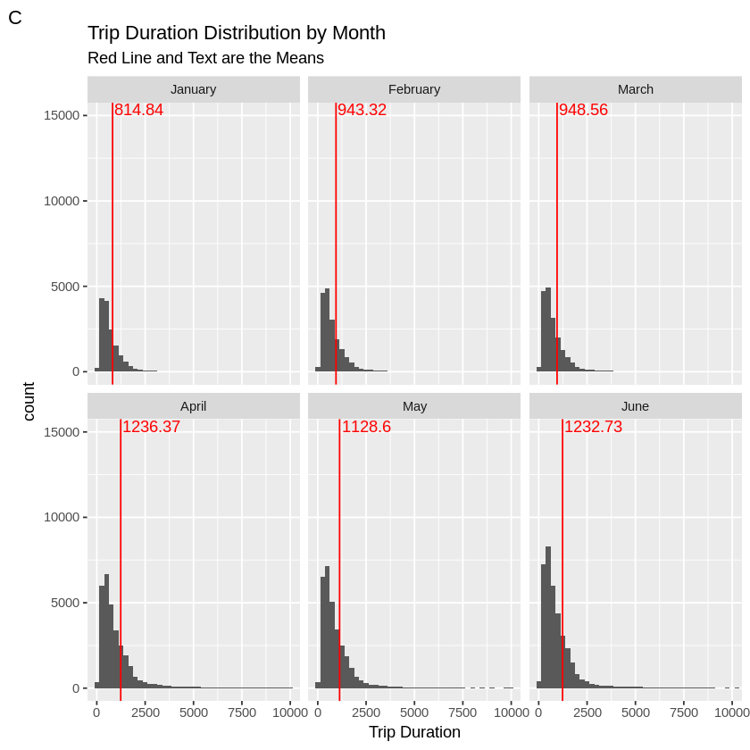

```r
ggplot(data = allCities) +
  geom_histogram(aes(x = Trip.Duration), binwidth = 250) +
  # geom_density(aes(x = Trip.Duration)) +
  coord_cartesian(xlim = c(0,10000)) +
  facet_wrap(facets = ~City) +
  geom_vline(data = cityStats, aes(xintercept = ave), color = "red") +
  geom_text(data = cityStats ,aes(x = ave + 100,
                label = round(ave, 2),
                y = 15000),
            hjust = 0, vjust = 0,
            color = "red") +
  labs(title = "Trip Duration Distribution by City",
       subtitle = "Red Line and Text are the Means",
       x = "Trip Duration",
       tag = "A")

ggplot(data = allCities) +
  geom_histogram(aes(x = Trip.Duration), binwidth = 250) +
  # geom_density(aes(x = Trip.Duration)) +
  coord_cartesian(xlim = c(0,10000)) +
  facet_wrap(facets = ~Gender) +
  geom_vline(data = genderStats, aes(xintercept = ave), color = "red") +
  geom_text(data = genderStats ,aes(x = ave + 100,
                label = round(ave, 2),
                y = 15000),
            hjust = 0, vjust = 0,
            color = "red") +
  labs(title = "Trip Duration Distribution by Gender",
       subtitle = "Red Line and Text are the Means",
       x = "Trip Duration",
       tag = "B")

ggplot(data = allCities) +
  geom_histogram(aes(x = Trip.Duration), binwidth = 250) +
  # geom_density(aes(x = Trip.Duration)) +
  coord_cartesian(xlim = c(0,10000)) +
  facet_wrap(facets = ~TripMonth) +
  geom_vline(data = monthStats, aes(xintercept = ave), color = "red") +
  geom_text(data = monthStats ,aes(x = ave + 100,
                label = round(ave, 2),
                y = 15000),
            hjust = 0, vjust = 0,
            color = "red") +
  labs(title = "Trip Duration Distribution by Month",
       subtitle = "Red Line and Text are the Means",
       x = "Trip Duration",
       tag = "C")
```

### Answer 2:

### 2A - Washington cyclists clearly have longer trips than the either Chicago or New York, which are about equal for trip length

### 2B - While there are clearly more male than female cyclists, it seems the female cyclists go for longer rides than their male counterparts. The "Unknown" category is primarily Washington cyclists.

### 2C - While the number of cycle rentals steadly increase from January to June, the length of the trips are shorter in the first quarter of the year than in the second quarter of the year, with the means differing by several hundred seconds.

## Question 3: What are the most desired locations in each city

### 3A - What are the locations people bike to most

### The output table shows the 3 most frequented destinations in each city

```r
# Your solution code goes here
endStations <- allCities %>% group_by(City, End.Station) %>%
  summarise(TripLength = mean(Trip.Duration, na.rm = T),
            NumTrips = n())

freqDest <- rbind((endStations %>% filter(City == "Washington") %>% arrange(desc(NumTrips)))[1:3, ],
             (endStations %>% filter(City == "Chicago") %>% arrange(desc(NumTrips)))[1:3, ],
             (endStations %>% filter(City == "NewYork") %>% arrange(desc(NumTrips)))[1:3, ])

freqDest
```

| City | End.Station | TripLength | NumTrips |
| --- | --- | --- | --- |
| Washington | Columbus Circle / Union Station | 896.9976 | 1767 |
| Washington | Jefferson Dr & 14th St SW | 2214.1323 | 1603 |
| Washington | Lincoln Memorial | 2062.1549 | 1514 |
| Chicago | Streeter Dr & Grand Ave | 1832.2275 | 233 |
| Chicago | Clinton St & Madison St | 598.7724 | 145 |
| Chicago | Theater on the Lake | 1639.6718 | 131 |
| NewYork | Pershing Square North | 748.3273 | 556 |
| NewYork | E 17 St & Broadway | 671.6831 | 445 |
| NewYork | Broadway & E 22 St | 702.1148 | 427 |

### 3B - What are the locations people are willing to endure a long bike ride for

### The output table shows the top 3 destinations (by length of journey) in each city to which at least 100 people made a trip in the first 6 months of 2017

```r
furtDest <- rbind((endStations %>% filter(City == "Washington", NumTrips > 99) %>% arrange(desc(TripLength)))[1:3, ],
                  (endStations %>% filter(City == "Chicago", NumTrips > 99) %>% arrange(desc(TripLength)))[1:3, ],
                  (endStations %>% filter(City == "NewYork", NumTrips > 99) %>% arrange(desc(TripLength)))[1:3, ])
furtDest
```

| City | End.Station | TripLength | NumTrips |
| --- | --- | --- | --- |
| Washington | 21st St & Constitution Ave NW | 4477.591 | 180 |
| Washington | 10th & Florida Ave NW | 3724.853 | 227 |
| Washington | Smithsonian-National Mall / Jefferson Dr & 12th St SW | 2740.057 | 1103 |
| Chicago | Streeter Dr & Grand Ave | 1832.227 | 233 |
| Chicago | Lake Shore Dr & Monroe St | 1802.904 | 115 |
| Chicago | Michigan Ave & Oak St | 1683.706 | 102 |
| NewYork | FDR Drive & E 35 St | 2200.632 | 125 |
| NewYork | Central Park West & W 72 St | 2022.500 | 156 |
| NewYork | 5 Ave & E 78 St | 1820.302 | 106 |

### 3C - Which spots were destinations for only one gender

### Output table shows destinations in each (of 2) cities visited by only a single gender

```r
# Summarizing inludes by gender
genderStations <- allCities %>% group_by(City, End.Station, Gender) %>%
  summarise(avLen = mean(Trip.Duration, na.rm = T),
            count = n())

# remove rows for which no gender was specified
genderStations <- genderStations[complete.cases(genderStations) , ]

# get the locations visited by only one gender
ms <- genderStations[genderStations$Gender == "Male" , "End.Station"]
fs <- genderStations[genderStations$Gender == "Female" , "End.Station"]
ms <- unlist(unname(ms))
fs <- unlist(unname(fs))
genderDiffF <- setdiff(ms, fs)
genderDiffM <- setdiff(fs, ms)


# crosscheck data on those locations
fOnly <- genderStations[which(genderStations$End.Station %in% genderDiffF) , ]
mOnly <- genderStations[which(genderStations$End.Station %in% genderDiffM), ]
genderOnly <- rbind(fOnly, mOnly)
genderOnly <- arrange(genderOnly, desc(City))
genderOnly
```

| City | End.Station | Gender | avLen | count |
| --- | --- | --- | --- | --- |
| NewYork | 10 Hudson Yards | Male | 728.3333 | 9 |
| NewYork | 3 Ave & Schermerhorn St | Male | 141.0000 | 1 |
| NewYork | Columbus Ave & W 103 St | Male | 1668.0000 | 4 |
| NewYork | Columbus Ave & W 103 St | Unknown | 548.0000 | 2 |
| NewYork | Division Ave & Marcy Ave | Male | 628.5000 | 2 |
| NewYork | Division Ave & Marcy Ave | Unknown | 1056.0000 | 3 |
| NewYork | E 53 St & Lexington Ave | Male | 707.5000 | 8 |
| NewYork | E 82 St & East End Ave | Male | 1401.5000 | 2 |
| NewYork | India St & West St | Male | 1657.0000 | 1 |
| NewYork | India St & West St | Unknown | 509.0000 | 1 |
| NewYork | LPI Facility | Male | 220.0000 | 1 |
| NewYork | Montague St & Clinton St | Male | 619.5000 | 6 |
| NewYork | Montague St & Clinton St | Unknown | 274.0000 | 1 |
| NewYork | NYCBS Depot - SSP | Male | 2260.0000 | 2 |
| NewYork | NYCBS Depot - STY | Male | 291.0000 | 1 |
| NewYork | Penn Station Valet - Valet Scan | Male | 748.3333 | 6 |
| NewYork | Richards St & Delavan St | Male | 762.8889 | 9 |
| NewYork | W 15 St & 10 Ave | Male | 1007.0000 | 3 |
| NewYork | Bike The Branches - Central Branch | Female | 2285.0000 | 1 |
| NewYork | Industry City, Building 1 Basement | Female | 1579.0000 | 1 |
| Chicago | 2112 W Peterson Ave | Male | 708.0000 | 1 |
| Chicago | Ashland Ave & 13th St | Male | 333.0000 | 2 |
| Chicago | Ashland Ave & Archer Ave | Male | 735.0000 | 1 |
| Chicago | Avers Ave & Belmont Ave | Male | 420.0000 | 1 |
| Chicago | Avers Ave & Belmont Ave | Unknown | 5289.5000 | 2 |
| Chicago | Avondale Ave & Irving Park Rd | Male | 577.5000 | 2 |
| Chicago | Benson Ave & Church St | Male | 560.3750 | 8 |
| Chicago | Benson Ave & Church St | Unknown | 1075.0000 | 1 |
| Chicago | Bosworth Ave & Howard St | Male | 628.0000 | 1 |
| Chicago | Budlong Woods Library | Male | 907.0000 | 1 |
| ⋮ | ⋮ | ⋮ | ⋮ | ⋮ |
| Chicago | Western Ave & 21st St | Male | 338.000 | 1 |
| Chicago | Western Ave & Granville Ave | Male | 2431.000 | 1 |
| Chicago | Western Ave & Lunt Ave | Male | 1003.500 | 2 |
| Chicago | Western Ave & Monroe St | Male | 1198.000 | 1 |
| Chicago | California Ave & Lake St | Female | 636.000 | 1 |
| Chicago | California Ave & Lake St | Unknown | 800.000 | 1 |
| Chicago | California Ave & Montrose Ave | Female | 732.000 | 1 |
| Chicago | Central St & Girard Ave | Female | 346.000 | 1 |
| Chicago | Chicago Ave & Sheridan Rd | Female | 1071.000 | 1 |
| Chicago | Chicago Ave & Sheridan Rd | Unknown | 2069.500 | 2 |
| Chicago | Clark St & Schreiber Ave | Female | 298.000 | 1 |
| Chicago | Clark St & Schreiber Ave | Unknown | 85408.000 | 1 |
| Chicago | Damen Ave & Coulter St | Female | 1089.000 | 1 |
| Chicago | Dorchester Ave & 49th St | Female | 819.000 | 1 |
| Chicago | Dorchester Ave & 49th St | Unknown | 1072.000 | 1 |
| Chicago | Emerald Ave & 28th St | Female | 524.000 | 2 |
| Chicago | Halsted St & 21st St | Female | 2355.000 | 1 |
| Chicago | Harper Ave & 59th St | Female | 344.500 | 2 |
| Chicago | Kedzie Ave & Lake St | Female | 1241.000 | 1 |
| Chicago | Kilbourn Ave & Irving Park Rd | Female | 1485.000 | 1 |
| Chicago | Lincoln Ave & Addison St | Female | 1895.000 | 2 |
| Chicago | Manor Ave & Leland Ave | Female | 65.000 | 1 |
| Chicago | Manor Ave & Leland Ave | Unknown | 1428.000 | 1 |
| Chicago | Oak Park Ave & Harrison St | Female | 1057.667 | 3 |
| Chicago | Racine Ave & 35th St | Female | 576.000 | 1 |
| Chicago | Racine Ave & 35th St | Unknown | 474.000 | 1 |
| Chicago | South Shore Dr & 71st St | Female | 1699.000 | 1 |
| Chicago | Warren Park East | Female | 818.000 | 1 |
| Chicago | Warren Park West | Female | 670.000 | 1 |
| Chicago | Wells St & 19th St | Female | 1129.000 | 1 |

### Answer 3

### There were many sites visited by only one gender, though those are not very frequently visited at all

### Most of those sites are in Chicago, with a small number of them in New York

## Finishing Up

> Congratulations! You have reached the end of the Explore Bikeshare Data Project. You should be very proud of all you have accomplished!

> **Tip**: Once you are satisfied with your work here, check over your report to make sure that it is satisfies all the areas of the [rubric](https://review.udacity.com/#!/rubrics/2508/view).

## Directions to Submit

> Before you submit your project, you need to create a .html or .pdf version of this notebook in the workspace here. To do that, run the code cell below. If it worked correctly, you should get a return code of 0, and you should see the generated .html file in the workspace directory (click on the orange Jupyter icon in the upper left).

> Alternatively, you can download this report as .html via the **File** > **Download as** submenu, and then manually upload it into the workspace directory by clicking on the orange Jupyter icon in the upper left, then using the Upload button.

> Once you've done this, you can submit your project by clicking on the "Submit Project" button in the lower right here. This will create and submit a zip file with this .ipynb doc and the .html or .pdf version you created. Congratulations!

```r
system('python -m nbconvert Explore_bikeshare_data.ipynb')
```